# CELL 1 :Imports for NumPy and Matplotlib for all plots

# CELL 14 : TASK 3 — equivalent PCA via SVD + a memory-light batched covariance that streams the data in chunks (handles datasets bigger than RAM). The prints confirm all routes agree.

```python
def pca_svd(X, n_components=None):
    '''Equivalent PCA via SVD of the centred data (no explicit covariance).'''
    Xc = X - X.mean(0)
    U, S, Vt = np.linalg.svd(Xc, full_matrices=False)
    eigvals = (S ** 2) / (X.shape[0] - 1)
    V = Vt.T
    if n_components is not None:
        eigvals, V = eigvals[:n_components], V[:, :n_components]
    return Xc @ V, eigvals, V

def batched_covariance(X, batch=10000):
    '''Memory-light covariance via streaming sums — handles data larger than RAM.'''
    n, d = X.shape
    s, ss = np.zeros(d), np.zeros((d, d))
    for i in range(0, n, batch):
        b = X[i:i+batch]
        s  += b.sum(0)
        ss += b.T @ b
    mean = s / n
    return (ss - n * np.outer(mean, mean)) / (n - 1)

_, e_svd, _ = pca_svd(X_std)
cov_batch   = batched_covariance(X_std, batch=128)
print("eigh vs svd  | max eigenvalue diff : %.2e" % np.max(np.abs(eigvals - e_svd)))
print("full vs batched covariance | max diff: %.2e" % np.max(np.abs(cov - cov_batch)))
```

```
eigh vs svd  | max eigenvalue diff : 2.28e-15
full vs batched covariance | max diff: 3.77e-15
```

# CELL 15 : Benchmark covariance+eigh vs full SVD on growing datasets. cov+eigh wins when rows >> features.

```python
sizes, d = [2000, 10000, 50000, 100000], 50
t_cov, t_svd = [], []
for n in sizes:
    Xb = rng.standard_normal((n, d))
    t0 = time.perf_counter(); pca_fit(Xb); t_cov.append(time.perf_counter() - t0)
    t0 = time.perf_counter(); pca_svd(Xb); t_svd.append(time.perf_counter() - t0)

print("  n rows     cov+eigh     SVD       speed-up")
for n, a, b in zip(sizes, t_cov, t_svd):
    print("  %-8d  %7.4fs   %7.4fs   %4.1fx" % (n, a, b, b / a))
```

```
  n rows     cov+eigh     SVD       speed-up
  2000       0.0039s    0.0265s    6.8x
  10000      0.0123s    0.0583s    4.7x
  50000      0.0487s    0.3213s    6.6x
  100000     0.1353s    0.6245s    4.6x
```

# CELL 16 : Plot the benchmark timings.

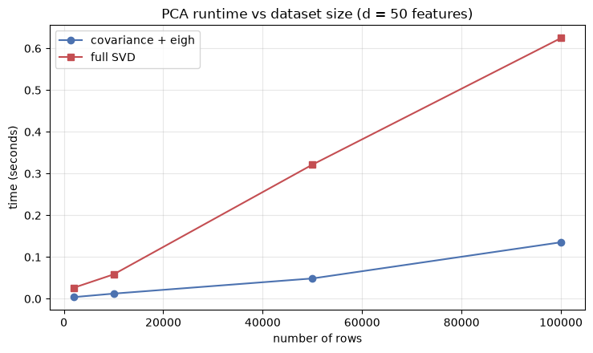

```python
fig, ax = plt.subplots(figsize=(7.5, 4.5))
ax.plot(sizes, t_cov, "o-", label="covariance + eigh", color="#4C72B0")
ax.plot(sizes, t_svd, "s-", label="full SVD",          color="#C44E52")
ax.set(title="PCA runtime vs dataset size (d = 50 features)",
       xlabel="number of rows", ylabel="time (seconds)")
ax.legend(); ax.grid(alpha=.3); plt.tight_layout(); plt.show()
```

# Conclusion

Using **only NumPy and Matplotlib**, we cleaned the data (handled `#N/B` missing values and encoded the categorical columns), standardised the 8 indicators, built PCA from scratch (covariance → sorted eigen-decomposition → projection), **dynamically selected k = 3** components (~97% variance), visualised the rotation from feature space to component space, and benchmarked two scalable implementations.